# AE 14: Confidence Invertals through Bootstrapping

due Thursday, June 2 at 9:29am

Bora Jin

## Getting Started

- Clone the repository entitled “ae14-GitHubUsername” at [course GitHub organization page](https://github.com/sta199-summer22) on your [RStudio](https://vm-manage.oit.duke.edu/containers).
- Open the `.Rmd` file and replace “Your Name” with your name.

## Rent in Manhattan

On a given day in 2018, twenty one-bedroom apartments were randomly selected on Craigslist Manhattan from apartments listed as “by owner”. The data are in the `manhattan` data frame. We will use this sample to conduct inference on the typical rent of one-bedroom apartments in Manhattan.

**Q -** State the research question and identify the population and our sample.

- Question:
- Population:
- Sample:

We start with loading relevant packages. For bootstrapping, we will use the `infer` package, included as part of `tidymodels`.

```r
library(tidyverse)
library(tidymodels)
```

```r
manhattan <- read_csv("data/manhattan.csv")
```

### Part 1: Parameter and point estimate

Let’s start by using bootstrapping to estimate the **mean** rent of one-bedroom apartments in Manhattan. Therefore,

- Parameter: Mean rent of all one-bedroom apartments in Manhattan
- Statistic: Mean rent of all apartments in the sample

**Q -** What is the point estimate of the mean rent?

### Part 2: Manual bootstrapping

Let’s bootstrap! We should start by setting a seed. Function `set.seed()` is a base `R` function that allows us to control `R`’s random number generation. This ensures our analysis is reproducible, which means we’ll get the same random sample each time we run the code or knit.

**Step 1**: Sample with replacement.

**Q -** How many observations do we need for our bootstrap sample?

```r
set.seed(123)

mht_boot1 <- manhattan %>%
  slice_sample(n = ___, replace = ___)

data.frame(org = manhattan$rent,
           boot1 = mht_boot1$rent)
```

**Step 2**: Compute the statistic from the bootstrap sample.

**Step 3**: Repeat steps 1 and 2 multiple times and create a bootstrap distribution of sample statistics.

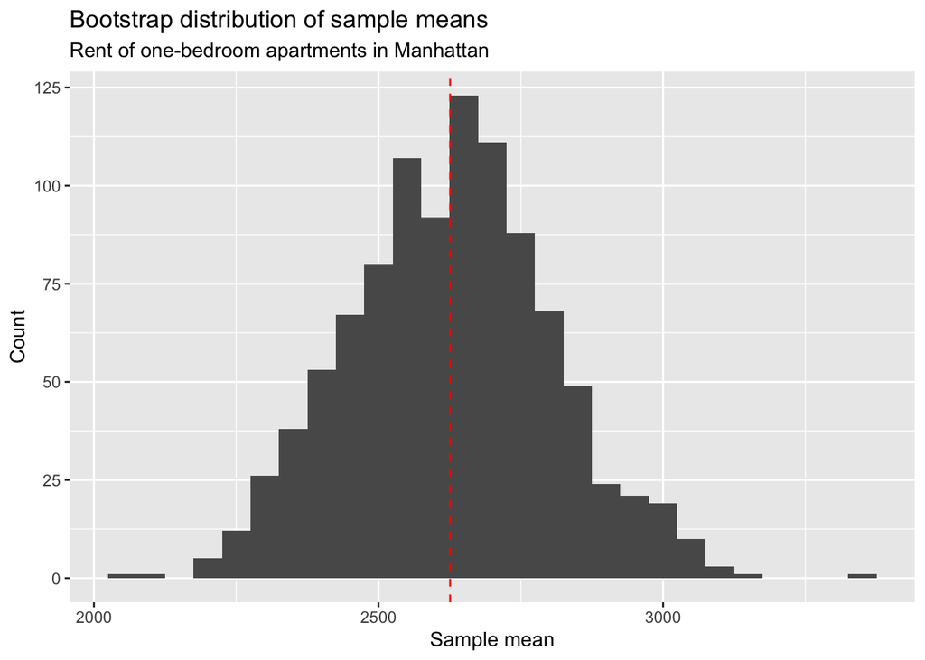

```r
set.seed(123)

# how many times?
reps <- 1000

# make a zero vector of length reps to save sample statistics
mean_rent <- rep(0, reps)

# repeat steps 1 and 2
for (i in 1:reps) {
  mht_boot <- manhattan %>%
  slice_sample(n = 20, replace = TRUE)
  mean_rent[i] <- mean(mht_boot$rent)
}

# histogram of the sample means
boot_dist <- tibble(replicate = 1:reps,
                      stat = mean_rent)
boot_dist %>%
  ggplot(aes(x = stat)) +
  geom_histogram(binwidth = 50) +
  geom_vline(xintercept = mean(manhattan$rent),
             color = "red", linetype = "dashed") +
  labs(x = "Sample mean", y = "Count",
       title = "Bootstrap distribution of sample means",
       subtitle = "Rent of one-bedroom apartments in Manhattan")
```

**Step 4**: Calculate a confidence interval (CI) using percentiles of the bootstrap distribution.

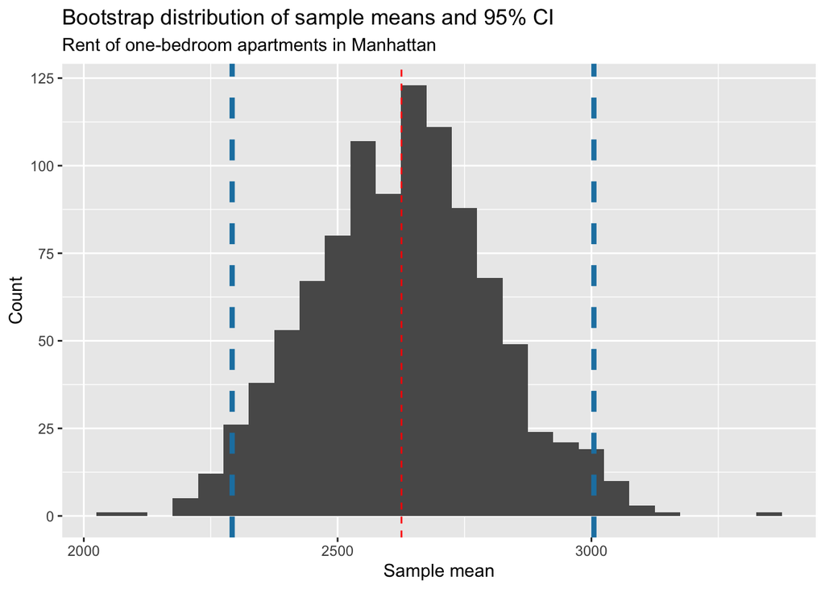

### Part 3: Bootstrap samples using functions in `infer`

**Steps 1-3** can be done in one pipeline using functions in `infer`.

**Q -** Complete the code chunk below.

```r
set.seed(123)

# save resulting bootstrap distribution
boot_dist2 <- manhattan %>%
  # specify the variable of interest
  specify(response = ____) %>%
  # generate reps (say 100, 1000, 10000, etc.) bootstrap samples
  generate(reps = ____, type = _____) %>%
  # calculate the statistic of each bootstrap sample
  calculate(stat = _____)
```

**Q -** How many rows are in `boot_dist2`?

**Q -** What does each row represent?

**Q -** What are the variables in `boot_dist2`? What do they mean?

**Q -** Visualize the bootstrap distribution using a histogram. Describe the shape, center, and spread of this distribution.

### Part 4: Confidence intervals

**Q - Step 4**. Construct the 95% confidence interval for the mean rent of one-bedroom apartments in Manhattan. To get middle 95%, we want to omit 2.5% on the left and on the right.

```r
boot_dist2 %>%
  summarize(lower_bound = quantile(____, ____),
            upper_bound = quantile(____, 0.975))
```

**Q -** What is the correct interpretation for the interval calculated above?

**Q -** Modify the code used to calculate a 95% confidence interval to calculate a 90% confidence interval for the mean rent of one-bedroom apartments in Manhattan. Hint: `upper` - `lower` should yield what you want, e.g., 0.975 - 0.025 = 0.95.

**Q -** Calculate a 99% confidence interval for the mean rent of one-bedroom apartments in Manhattan. How does the width of this interval compare to the width of the 90% or the 95% confidence interval?

**Q -** What is one advantage to using a 90% confidence interval instead of a 95% confidence interval to estimate a parameter? What is one advantage to using a 99% confidence interval instead of a 95% confidence interval to estimate a parameter? Explain in terms of accuracy and precision.

### Practice

Use bootstrapping to estimate the **median** rent for one-bedroom apartments in Manhattan.

1. Generate the bootstrap distribution of the sample medians. Use 1000 reps. Save the results in `boot_dist_median`.

```r
set.seed(123)
```

2. Calculate a 92% confidence interval.
3. Interpret the 92% confidence interval.

## Submitting Application Exercises

- Once you have completed the activity, push your final changes to your GitHub repo.
- Make sure you committed at least *three* times.
- Check that your repo is updated on GitHub, and that’s all you need to do to submit application exercises for participation.